# Chapter 4.5-4.6: Log-linear and Log-log Models

Sections 4.5 and 4.6

# Log Models Made Simple

We move from ordinary unit changes to percentage changes and elasticity, one idea at a time.

1. Why logs?

2. Log-linear

3. Prediction

4. Log-log

Start here

## What are we trying to learn?

A coefficient in an ordinary linear regression described an **absolute change**.

For example, in

$$y = \beta_1 + \beta_2 x + e$$

a one-unit increase in $x$ is associated with a $\beta_2$-unit change in $y$.

In Sections 4.5 and 4.6, the question changes:

- What if we want to talk about a **percentage change in $y$**?
- What if we want to talk about a **percentage change in both $x$ and $y$**?

That is why we use logarithms.

**The big idea**  
Log models are useful because they let us express economic relationships in percentage terms.

### Two models for today

**Log-linear**

$$\ln(y) = \beta_1 + \beta_2 x + e$$

A one-unit increase in $x$ is associated with approximately a $100\beta_2\%$ change in $y$.

**Log-log**

$$\ln(y) = \beta_1 + \beta_2\ln(x) + e$$

A 1% increase in $x$ is associated with approximately a $\beta_2\%$ change in $y$.

Quick retrieval question

If the coefficient on $x$ in an ordinary linear model is $4.2$, what does it mean?

**Answer:** a one-unit increase in $x$ is associated with a 4.2-unit change in $y$, on average.

**Instructor cue**

Begin with interpretation, not algebra. Ask students why economists often say “wages are 10% higher” or “demand elasticity is -1.2” instead of reporting only unit changes.

Step 1

## Why take logarithms?

The chapter notes that variables such as wages, income, prices, sales, and expenditures are often positive and right-skewed. Taking logs compresses large values and often makes percentage interpretation more natural.

**Important:** $\ln(y)$ requires $y>0$, and $\ln(x)$ requires $x>0$.

### A simple numerical illustration

**Show R code**

```r
x <- c(1, 2, 5, 10, 20, 50, 100)
data.frame(x = x, log_x = round(log(x), 3))
```

```
    x log_x
1   1 0.000
2   2 0.693
3   5 1.609
4  10 2.303
5  20 2.996
6  50 3.912
7 100 4.605
```

Prediction before looking

Which change is larger in absolute terms: 10 to 20, or 90 to 100?

Which change is larger in percentage terms?

Both are increases of 10 units, but 10 to 20 is a 100% increase while 90 to 100 is only about 11.1%. Logs help us focus on relative changes.

Step 2 — Section 4.5

## Log-linear model: unit change in $x$, percentage change in $y$

The model is

$$\ln(y) = \beta_1 + \beta_2 x + e$$

The key interpretation is

$$\boxed{
\text{1-unit increase in }x
\Rightarrow
\text{approximately }100\beta_2\%\text{ change in }y
}$$

That is the main idea to remember.

### Textbook example: wage and education

$$ln(\text{wage})=\beta_1+\beta_2 \times \text{education}+e$$

**Show R code**

```r
#' Example 4.10 - Wage Equation, log-linear model
rm(list=ls())
load(url("http://www.principlesofeconometrics.com/poe5/data/rdata/cps5_small.rdata"))
head(cps5_small)
```

```
  black educ exper faminc female metro midwest south  wage west
1     0   13    45      0      1     1       0     0 44.44    1
2     0   14    25  45351      1     1       1     0 16.00    0
3     0   18    27  91946      1     1       0     0 15.38    0
4     0   13    42  48370      0     1       1     0 13.54    0
5     0   13    41  10000      1     1       0     0 25.00    1
6     0   16    26 151308      1     1       0     0 24.05    0
```

**Show R code**

```r
cps5 <- cps5_small
rm(cps5_small)

#summary(cps5$wage)

#' Estimated model
m1 <- lm(log(wage)~educ, data=cps5)
summary(m1)
```

```
Call:
lm(formula = log(wage) ~ educ, data = cps5)

Residuals:
    Min      1Q  Median      3Q     Max
-1.8227 -0.3262 -0.0131  0.3382  2.2217

Coefficients:
            Estimate Std. Error t value Pr(>|t|)
(Intercept) 1.596835   0.070180   22.75   <2e-16 ***
educ        0.098753   0.004842   20.39   <2e-16 ***
---
Signif. codes:  0 '***' 0.001 '**' 0.01 '*' 0.05 '.' 0.1 ' ' 1

Residual standard error: 0.4847 on 1198 degrees of freedom
Multiple R-squared:  0.2577,    Adjusted R-squared:  0.2571
F-statistic: 415.9 on 1 and 1198 DF,  p-value: < 2.2e-16
```

The coefficient on education is about $0.099$.

So

$$100(0.099)=9.9\%$$

Therefore:

> One additional year of education is associated with approximately **9.9% higher wages**, on average.

**Show R code**

```r
library(mosaic)
100*confint(m1)
```

```
                 2.5 %    97.5 %
(Intercept) 145.914565 173.45251
educ          8.925329  10.82535
```

What does $0.099$ NOT mean?

It does not mean that wage rises by $0.099. Because the dependent variable is logged, the coefficient is interpreted approximately as a percentage effect.

### Approximate and exact percentage effects

For a one-unit increase in $x$, the simple approximation is

$$100\beta_2$$

The exact percentage effect is

$$100\left(e^{\beta_2}-1\right)$$

For $\beta_2=0.099$:

**Show R code**

```r
beta <- 0.099
approx_pct <- 100 * beta
exact_pct <- 100 * (exp(beta) - 1)
c(approximate = approx_pct, exact = exact_pct)
```

```
approximate       exact
    9.90000    10.40663
```

**Teaching rule:** for a small coefficient, $100\beta_2$ is usually a good approximation. For larger coefficients, use the exact formula.

### Interactive: when does the approximation matter?

**Choose β₂** 0.099

Approximate effect

9.90%

Exact effect

10.41%

Difference

0.51 pp

**Optional derivation**

A one-unit increase in $x$ changes fitted log outcome by $\beta_2$:

$$\Delta\ln(y)=\beta_2$$

For small changes,

$$\Delta\ln(y) \approx \frac{\Delta y}{y}$$

so

$$100\frac{\Delta y}{y}\approx100\beta_2.$$

Students do not need to memorize this derivation if they can interpret the coefficient correctly.

Step 3 — Section 4.5.1

## Prediction when the dependent variable is logged

Suppose we estimate

$$\widehat{\ln(y)} = b_1 + b_2x$$

A natural idea is to exponentiate:

$$\hat y_{\text{natural}}
=
\exp(b_1+b_2x)$$

But the chapter explains that this natural predictor tends to underpredict $y$ in a log-linear model.

For a sufficiently large sample, the chapter uses the corrected predictor

$$\hat y_{\text{corrected}}
=
\exp\left(b_1+b_2x+\frac{\hat\sigma^2}{2}\right)$$

**Show R code**

```r
#' Sums of squared residuals, SSE
deviance(m1)
```

```
[1] 281.4487
```

**Show R code**

```r
#' The variance in the model, sigma squared
deviance(m1)/m1$df.residual
```

```
[1] 0.2349321
```

**Show R code**

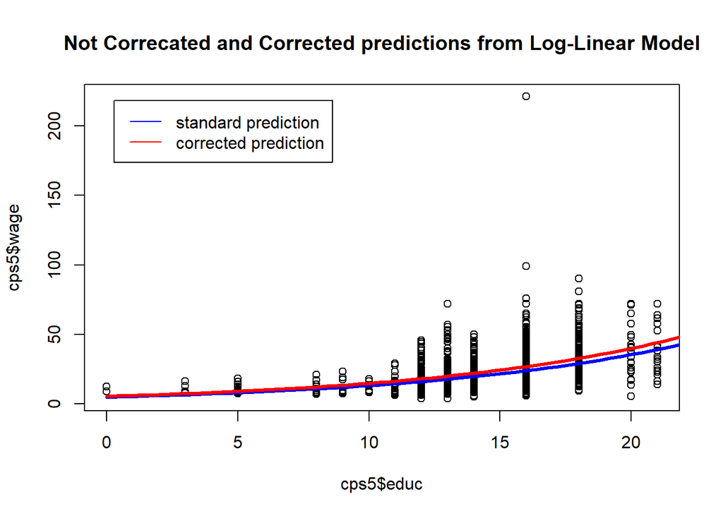

```r
s2 <- deviance(m1)/m1$df.residual

#' Predictions in the log-linear model
yn <- function(x) {exp(coef(m1)[1]+coef(m1)[2]*x)} # not corrected
yc <- function(x) {exp(coef(m1)[1]+coef(m1)[2]*x+s2/2)} # corrected

plot(cps5$educ,cps5$wage, main="Not Correcated and Corrected predictions from Log-Linear Model")
curve(yn, 0,40, lwd=3, add=T, col="blue")
curve(yc, 0,40, lwd=3, col="red", add=T)
legend("topleft", c("standard prediction","corrected prediction"),
       col=c("blue","red"), inset = 0.05, lty=1, cex=1)
```

### Textbook wage prediction at 12 years of education

**Show R code**

```r
#' Prediction intervals in a log-linear model

yn(12)
```

```
(Intercept)
   16.14929
```

**Show R code**

```r
yc(12)
```

```
(Intercept)
    18.1622
```

**Show R code**

```r
f <- makeFun(m1)
#' Expected value in levels
f(12, interval='prediction')
```

```
       fit      lwr      upr
1 16.14929 6.235749 41.82331
```

**Show R code**

```r
f(12)*exp(s2/2) # must adjust
```

```
      1
18.1622
```

- predicted $\ln(WAGE)=2.7819$,
- natural prediction about **$16.15**,
- corrected prediction about **$18.16**.

Why is the corrected prediction larger?

Because the correction multiplies the natural predictor by $\exp(\hat\sigma^2/2)$, which is greater than 1 when $\hat\sigma^2>0$.

**Student takeaway:** predicting $\ln(y)$ and predicting $y$ are not the same thing.

### Interactive illustration

**Years of education** 12

Predicted ln(wage)

2.782

Natural prediction

$16.15

Corrected prediction

$18.16

### Prediction interval: another important distinction

The chapter reports a 95% prediction interval for the wage of a worker with 12 years of education of approximately

$$\boxed{\$6.24\text{ to }\$41.82}$$

That interval is very wide.

What should students learn from that?

A model can estimate an average percentage relationship reasonably well and still be a poor predictor of an individual person’s wage.

**Optional technical note: generalized $R^2$**

In a log-linear model, the ordinary software $R^2$ describes variation in $\ln(y)$, not directly variation in $y$.

The chapter therefore discusses a generalized goodness-of-fit measure based on the squared correlation between actual $y$ and the best prediction $\hat y$:

$$R^2_{gen} = \left[\operatorname{corr}(y,\hat y)\right]^2$$

For the wage example, the chapter reports about $0.2159$ for this generalized measure, compared with about $0.2577$ for the usual $R^2$ from the regression in $\ln(WAGE)$.

**Show R code**

```r
#' A generalized $R^{2}$ measure
cor(cps5$wage,yc(cps5$educ))
```

```
[1] 0.4647035
```

**Show R code**

```r
cor(cps5$wage,yc(cps5$educ))^2
```

```
[1] 0.2159494
```

**Show R code**

```r
summary(m1)$r.squared
```

```
[1] 0.2577126
```

**Show R code**

```r
#summary(m1)
```

Step 4 — Section 4.6

## Log-log model: percentage change in $x$, percentage change in $y$

Now suppose both variables are logged:

$$\ln(y)=\beta_1+\beta_2\ln(x)+e$$

The interpretation becomes especially convenient:

$$\boxed{\beta_2 = \text{elasticity of }y\text{ with respect to }x}$$

So:

$$\boxed{
1\% \text{increase in }x
\Rightarrow
\text{approximately }\beta_2\%\text{ change in }y
}$$

### Why economists like this model

Elasticity is a percentage-on-percentage measure, so it does not depend on the units used to measure $x$ and $y$.

Suppose $\beta_2=-1.5$. What does it mean?

A 1% increase in $x$ is associated with approximately a 1.5% decrease in $y$.

### Textbook example: poultry demand

The chapter reports an estimated price elasticity of demand of about

$$\hat\beta_2=-1.121$$

Therefore:

> A 1% increase in the real price of chicken is associated with approximately a **1.121% decrease in quantity consumed**.

### What about a 10% price increase?

Using the constant-elasticity interpretation,

$$\%\Delta Q \approx \beta_2\times \%\Delta P$$

so

$$\%\Delta Q \approx (-1.121)(10)=-11.21\%$$

Thus a 10% increase in price is associated with approximately an 11.21% decrease in quantity demanded.

### Interactive elasticity calculator

**Price change (%)** 10%

Elasticity

-1.121

Approx. quantity change

-11.21%

**Core distinction:**  
Log-linear: 1 unit in $x$ $\rightarrow$ % change in $y$.  
Log-log: 1% in $x$ $\rightarrow$ % change in $y$.

**Optional derivation of elasticity**

Start with

$$\ln(y)=\beta_1+\beta_2\ln(x)$$

Then small changes satisfy

$$\%\Delta y \approx \beta_2\,\%\Delta x$$

which is why $\beta_2$ is the elasticity.

Compare

## Do not mix up the models

| Model | Equation | Meaning of $\beta_2$ |
| --- | --- | --- |
| Linear | $y=\beta_1+\beta_2x+e$ | 1-unit increase in $x$ $\rightarrow$ $\beta_2$ units in $y$ |
| Log-linear | $\ln(y)=\beta_1+\beta_2x+e$ | 1-unit increase in $x$ $\rightarrow$ about $100\beta_2\%$ in $y$ |
| Log-log | $\ln(y)=\beta_1+\beta_2\ln(x)+e$ | 1% increase in $x$ $\rightarrow$ about $\beta_2\%$ in $y$ |

### A quick decision rule

Before interpreting any coefficient, ask:

1. Is $y$ logged?
2. Is $x$ logged?
3. Am I talking about units or percentages?

**Common mistake:** saying “log means percentage” without checking which variable is logged.

Practice

## Three quick checks

### Check 1

$$\ln(SALES)=4.10-0.07PRICE$$

What does $-0.07$ mean?

**Answer**

A $1 increase in PRICE is associated with approximately a 7% decrease in SALES.

### Check 2

$$\ln(Q)=3.2-1.5\ln(P)$$

What does $-1.5$ mean?

**Answer**

The price elasticity of demand is $-1.5$. A 1% increase in price is associated with approximately a 1.5% decrease in quantity demanded.

### Check 3

A student says:

> “In a log-linear wage model, $\beta_2=0.08$ means one more year of education increases wage by $0.08.”

What is wrong?

**Answer**

The dependent variable is logged. The interpretation is approximately an 8% increase in wage, not a $0.08 increase.

AI audit

## Can you catch a plausible interpretation error?

Give an AI this prompt:

> A regression gives $\ln(WAGE)=1.7+0.09EDUC$. Explain the coefficient on EDUC and predict the effect of two additional years of education.

Then audit the answer:

- Did it interpret $0.09$ as about 9% per year?
- Did it distinguish approximate from exact percentage change?
- Did it avoid saying the model proves a causal return to education?
- For two years, did it simply double the approximation, or explain the exact compounded effect?

For the exact two-year effect,

$$100\left(e^{2(0.09)}-1\right)$$

is more accurate than simply saying 18%.

Exit problem

## Can you identify the model and interpret it correctly?

A researcher estimates

$$\ln(DEMAND)=5.4-0.8\ln(PRICE)$$

Answer these two questions:

1. What type of model is this?
2. What does $-0.8$ mean?

**Expected answer**

It is a log-log model. The estimated price elasticity is $-0.8$, so a 1% increase in price is associated with approximately a 0.8% decrease in demand.

**Single most important idea:** students should not memorize “logs mean percentages.” They should first identify which variable is logged, then interpret the coefficient accordingly.